# Unemployment and Voter Turnout Analysis

Research Question 1: How does local Unemployment tier relate to voter turnout?

Author

Statistical Analysis - STA 702

Published

December 10, 2025

# **Theoretical Motivation - Political Participation Framework**

Political theory suggests that populations differ in their typical level of political engagement. Almond and Verba’s classic “Civic Culture” framework describes a participation pyramid in which the largest group consists of disengaged citizens (“parochials”), followed by moderately involved voters (“subjects”), and finally a small group of highly engaged participants.

In many systems, this bottom tier, often described as a “silent majority”, remains politically inactive unless economic or social conditions deteriorate. Under worsening economic conditions, previously uninvolved citizens may become mobilized to vote, either to punish the incumbent or express dissatisfaction with the status quo.

Berelson, Bernard R., Paul F. Lazarsfeld, and William N. McPhee. *Voting: A Study of Opinion Formation in a Presidential Campaign.* University of Chicago Press, 1954.

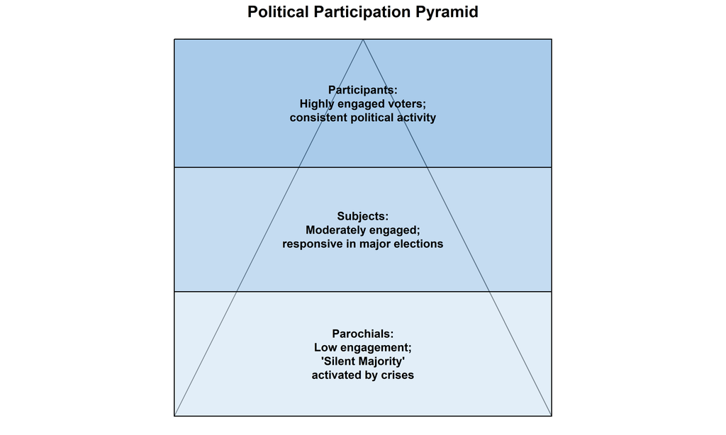

```r
library(ggplot2)
library(dplyr)

# Data: three layers of the participation pyramid
pyramid_df <- tibble(
  level = factor(c("Participants", "Subjects", "Parochials"),
                 levels = c("Participants", "Subjects", "Parochials")),
  ymin = c(0.66, 0.33, 0),
  ymax = c(1, 0.66, 0.33),
  label = c(
    "Participants:\nHighly engaged voters;\nconsistent political activity",
    "Subjects:\nModerately engaged;\nresponsive in major elections",
    "Parochials:\nLow engagement;\n'Silent Majority'\nactivated by crises"
  )
)

# Base triangle shape
triangle <- data.frame(
  x = c(0.5, 1, 0),
  y = c(1, 0, 0)
)

ggplot() +
  # Triangle outline
  geom_polygon(data = triangle, aes(x, y), fill = "white", color = "black") +

  # Layers inside the triangle
  geom_rect(data = pyramid_df,
            aes(xmin = 0, xmax = 1, ymin = ymin, ymax = ymax, fill = level),
            alpha = 0.6, color = "black") +

  # Descriptive text inside each layer
  geom_text(data = pyramid_df,
            aes(x = 0.5, y = (ymin + ymax) / 2, label = label),
            color = "black", size = 4, lineheight = 1,
            fontface = "bold") +

  scale_fill_manual(values = c(
    "Participants" = "#6fa8dc",
    "Subjects" = "#9fc5e8",
    "Parochials" = "#cfe2f3"
  )) +

  coord_fixed() +
  theme_void() +
  theme(
    legend.position = "none",
    plot.title = element_text(size = 16, face = "bold", hjust = 0.5)
  ) +
  ggtitle("Political Participation Pyramid")
```

# Introduction

This analysis investigates the relationship between local economic conditions (measured by unemployment rate) and voter turnout in U.S. presidential and midterm elections from 2004-2022. Our data comes from the Inter-university Consortium for Political and Social Research (ICPSR) and the Bureau of Labor Statistics.

**Research Question:** How does local unemployment relate to voter turnout in U.S. elections at the county level?

**Key Measures:**

- **Outcome:** County-level voter turnout rate (proportion of eligible voters who voted)
- **Predictor:** County unemployment rate (annual average, %)
- **Interaction:** Unemployment effect by county type (Urban, Suburban, or Rural)

# Data Preparation

```r
# Load required packages
library(tidyverse)
library(lfe)           # For fixed effects regression
library(stargazer)     # For regression tables
library(ggplot2)
library(knitr)
library(gridExtra)

# Set ggplot theme
theme_set(theme_minimal(base_size = 12))
```

```r
# Load the merged dataset
df <- read_csv("../data/processed/merged_voting_unemployment_complete.csv",
               show_col_types = FALSE)

# Display data structure
cat("Dataset Overview:\n")
```

```
Dataset Overview:
```

```r
cat("Observations:", nrow(df), "\n")
```

```
Observations: 30912
```

```r
cat("Counties:", length(unique(df$FIPS)), "\n")
```

```
Counties: 3103
```

```r
cat("Years:", min(df$YEAR), "-", max(df$YEAR), "\n")
```

```
Years: 2004 - 2022
```

```r
cat("Variables:", ncol(df), "\n")
```

```
Variables: 21
```

**Data Cleaning**

```r
# Clean the dataset
df <- df%>%
  filter(
    VOTER_TURNOUT_PCT > 0,           # Drop zero turnout
    !is.na(VOTER_TURNOUT_PCT),       # Drop missing turnout
    !is.na(unemployment_rate),        # Drop missing unemployment
    VOTER_TURNOUT_PCT <= 1.0         # Sanity check: turnout ≤ 100%
  )

cat("CLEANED DATASET\n")
```

```
CLEANED DATASET
```

```r
cat("===============\n")
cat("Observations remaining:", nrow(df), "\n")
```

```
Observations remaining: 29769
```

## Variable Creation

```r
## Variable Creation
df <- df %>%
  mutate(
    # Election type indicator
    is_presidential = ifelse(YEAR %% 4 == 0, 1, 0),
    election_type = ifelse(is_presidential == 1, "Presidential", "Midterm"),

    # Unemployment tiers based on standard deviations from mean
    unemp_mean = mean(unemployment_rate, na.rm = TRUE),
    unemp_sd = sd(unemployment_rate, na.rm = TRUE),

    # Calculate z-score
    unemp_zscore = (unemployment_rate - unemp_mean) / unemp_sd,

    # Create tier classifications
    unemployment_tier = case_when(
      unemp_zscore < -1.0 ~ "Very Low (< -1 SD)",
      unemp_zscore < -0.5 ~ "Low (-1 to -0.5 SD)",
      unemp_zscore < 0.5  ~ "Medium (-0.5 to 0.5 SD)",
      unemp_zscore < 1.0  ~ "High (0.5 to 1 SD)",
      TRUE                ~ "Very High (> 1 SD)"
    ),

    # Ordered factor for modeling
    unemployment_tier = factor(unemployment_tier,
                              levels = c("Very Low (< -1 SD)",
                                        "Low (-1 to -0.5 SD)",
                                        "Medium (-0.5 to 0.5 SD)",
                                        "High (0.5 to 1 SD)",
                                        "Very High (> 1 SD)"),
                              ordered = TRUE),

    # Standardized variables
    unemployment_std = (unemployment_rate - mean(unemployment_rate)) /
                       sd(unemployment_rate),

    # Urban/rural classification based on CVAP
    county_type = case_when(
      CVAP > 50000 ~ "Urban",
      CVAP > 10000 ~ "Suburban",
      TRUE ~ "Rural"
    ),

    # Factor variables for regression
    FIPS_factor = as.factor(FIPS),
    YEAR_factor = as.factor(YEAR),
    STATE_factor = as.factor(STATE_FIPS)
  )

# Summary of unemployment tier distribution
cat("✓ Created classification variables\n")
```

```
✓ Created classification variables
```

```r
cat("  - Mean unemployment:", round(df$unemp_mean[1], 2), "%\n")
```

```
  - Mean unemployment: 5.95 %
```

```r
cat("  - SD unemployment:", round(df$unemp_sd[1], 2), "%\n\n")
```

```
  - SD unemployment: 2.67 %
```

```r
cat("Distribution of unemployment tiers:\n")
```

```
Distribution of unemployment tiers:
```

```r
df %>%
  count(unemployment_tier) %>%
  mutate(percent = round(100 * n / sum(n), 1)) %>%
  kable(col.names = c("Unemployment Tier", "N", "Percent (%)"))
```

| Unemployment Tier | N | Percent (%) |
| --- | --- | --- |
| Very Low (< -1 SD) | 3744 | 12.6 |
| Low (-1 to -0.5 SD) | 7343 | 24.7 |
| Medium (-0.5 to 0.5 SD) | 10916 | 36.7 |
| High (0.5 to 1 SD) | 3378 | 11.3 |
| Very High (> 1 SD) | 4388 | 14.7 |

# Descriptive Statistics

## Summary Statistics

```r
# Overall summary
df %>%
  select(VOTER_TURNOUT_PCT, unemployment_rate, CVAP) %>%
  summary() %>%
  kable(caption = "Summary Statistics: Key Variables", digits = 3)
```

Summary Statistics: Key Variables

|  | VOTER_TURNOUT_PCT | unemployment_rate | CVAP |
| --- | --- | --- | --- |
|  | Min. :0.000022 | Min. : 1.100 | Min. : 60 |
|  | 1st Qu.:0.432753 | 1st Qu.: 4.000 | 1st Qu.: 8420 |
|  | Median :0.533551 | Median : 5.400 | Median : 19525 |
|  | Mean :0.526300 | Mean : 5.949 | Mean : 72253 |
|  | 3rd Qu.:0.625247 | 3rd Qu.: 7.400 | 3rd Qu.: 51010 |
|  | Max. :0.980000 | Max. :29.100 | Max. :7843598 |

## Distribution by Groups

```r
# By election type
df %>%
  group_by(election_type) %>%
  summarise(
    N = n(),
    Avg_Turnout = mean(VOTER_TURNOUT_PCT, na.rm = TRUE),
    SD_Turnout = sd(VOTER_TURNOUT_PCT, na.rm = TRUE),
    Avg_Unemployment = mean(unemployment_rate, na.rm = TRUE),
    SD_Unemployment = sd(unemployment_rate, na.rm = TRUE)
  ) %>%
  kable(caption = "Statistics by Election Type", digits = 3)
```

Statistics by Election Type

| election_type | N | Avg_Turnout | SD_Turnout | Avg_Unemployment | SD_Unemployment |
| --- | --- | --- | --- | --- | --- |
| Midterm | 14836 | 0.445 | 0.128 | 5.602 | 2.909 |
| Presidential | 14933 | 0.607 | 0.107 | 6.295 | 2.352 |

```r
# By county type
df %>%
  group_by(county_type) %>%
  summarise(
    N = n(),
    Counties = n_distinct(FIPS),
    Avg_Turnout = mean(VOTER_TURNOUT_PCT, na.rm = TRUE),
    SD_Turnout = sd(VOTER_TURNOUT_PCT, na.rm = TRUE),
    Avg_Unemployment = mean(unemployment_rate, na.rm = TRUE),
    SD_Unemployment = sd(unemployment_rate, na.rm = TRUE)
  ) %>%
  kable(caption = "Statistics by County Type", digits = 3)
```

Statistics by County Type

| county_type | N | Counties | Avg_Turnout | SD_Turnout | Avg_Unemployment | SD_Unemployment |
| --- | --- | --- | --- | --- | --- | --- |
| Rural | 8660 | 941 | 0.567 | 0.144 | 5.396 | 2.757 |
| Suburban | 13548 | 1499 | 0.506 | 0.137 | 6.295 | 2.618 |
| Urban | 7561 | 829 | 0.515 | 0.144 | 5.963 | 2.540 |

```r
# By unemployment tier
df %>%
  group_by(unemployment_tier) %>%
  summarise(
    N = n(),
    Avg_Turnout = mean(VOTER_TURNOUT_PCT, na.rm = TRUE),
    SD_Turnout = sd(VOTER_TURNOUT_PCT, na.rm = TRUE),
    Avg_Unemployment = mean(unemployment_rate, na.rm = TRUE),
    Min_Unemployment = min(unemployment_rate, na.rm = TRUE),
    Max_Unemployment = max(unemployment_rate, na.rm = TRUE)
  ) %>%
  kable(caption = "Statistics by Unemployment Tier", digits = 3)
```

Statistics by Unemployment Tier

| unemployment_tier | N | Avg_Turnout | SD_Turnout | Avg_Unemployment | Min_Unemployment | Max_Unemployment |
| --- | --- | --- | --- | --- | --- | --- |
| Very Low (< -1 SD) | 3744 | 0.535 | 0.151 | 2.728 | 1.1 | 3.2 |
| Low (-1 to -0.5 SD) | 7343 | 0.523 | 0.152 | 3.970 | 3.3 | 4.6 |
| Medium (-0.5 to 0.5 SD) | 10916 | 0.536 | 0.138 | 5.824 | 4.7 | 7.2 |
| High (0.5 to 1 SD) | 3378 | 0.528 | 0.139 | 7.902 | 7.3 | 8.6 |
| Very High (> 1 SD) | 4388 | 0.501 | 0.134 | 10.818 | 8.7 | 29.1 |

# Visualizations

## By Election Type

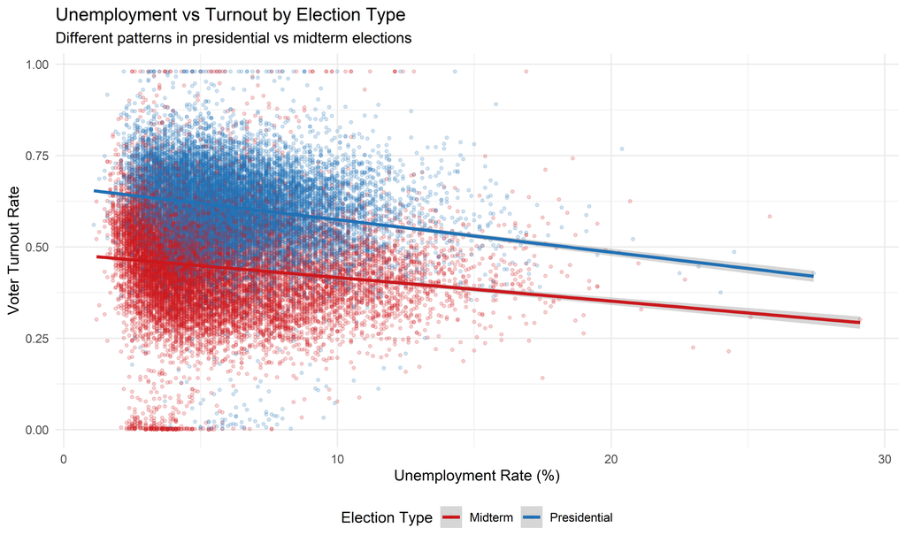

Unemployment vs Turnout by Election Type

```r
ggplot(df, aes(x = unemployment_rate, y = VOTER_TURNOUT_PCT,
               color = election_type)) +
  geom_point(alpha = 0.2, size = 1) +
  geom_smooth(method = "lm", se = TRUE, size = 1.2) +
  scale_color_manual(values = c("Presidential" = "#2171b5", "Midterm" = "#cb181d")) +
  labs(
    title = "Unemployment vs Turnout by Election Type",
    subtitle = "Different patterns in presidential vs midterm elections",
    x = "Unemployment Rate (%)",
    y = "Voter Turnout Rate",
    color = "Election Type"
  ) +
  theme_minimal(base_size = 12) +
  theme(legend.position = "bottom")
```

## Interaction Effect: County Type

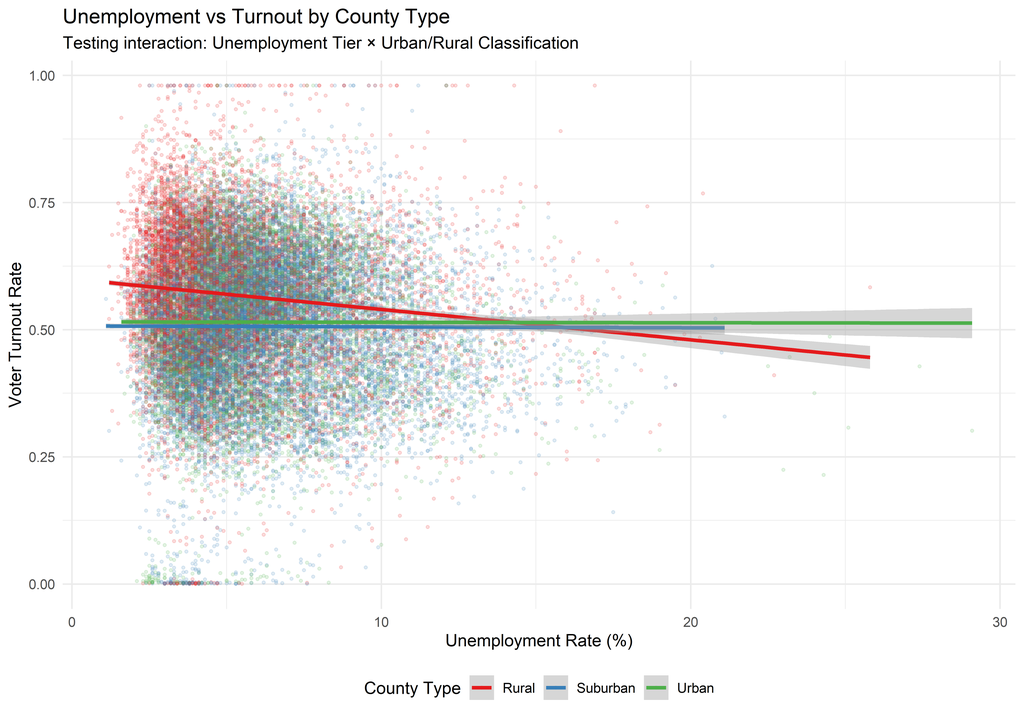

Testing Interaction: Unemployment tier × Urban/Rural

```r
ggplot(df, aes(x = unemployment_rate, y = VOTER_TURNOUT_PCT,
               color = county_type)) +
  geom_point(alpha = 0.15, size = 0.8) +
  geom_smooth(method = "lm", se = TRUE, size = 1.2) +
  scale_color_brewer(palette = "Set1") +
  labs(
    title = "Unemployment vs Turnout by County Type",
    subtitle = "Testing interaction: Unemployment Tier × Urban/Rural Classification",
    x = "Unemployment Rate (%)",
    y = "Voter Turnout Rate",
    color = "County Type"
  ) +
  theme_minimal(base_size = 12) +
  theme(legend.position = "bottom")
```

## Boxplot: Interaction Visualization

[figure not shown]

Turnout by County Type and Economic Condition

```r
ggplot(df, aes(x = county_type, y = VOTER_TURNOUT_PCT, fill = unemployment_tier)) +
  geom_boxplot(alpha = 0.8) +
  scale_fill_manual(values = c("Low Unemployment" = "#31a354",
                                "High Unemployment" = "#e34a33")) +
  labs(
    title = "Voter Turnout by County Type and Economic Condition",
    subtitle = "Comparing high vs low unemployment periods",
    x = "County Type",
    y = "Voter Turnout Rate",
    fill = "Economic Condition"
  ) +
  theme_minimal(base_size = 12) +
  theme(legend.position = "bottom")
```

# Regression Analysis

## Model Specification

**Reference Category:** Rural counties serve as the baseline. The main unemployment coefficient represents the effect for rural counties, with interaction terms showing how suburban and urban counties differ from this baseline.

## Model Estimation

```r
# Ensure Rural is the reference category
df <- df %>%
  mutate(county_type = factor(county_type, levels = c("Rural", "Suburban", "Urban")))

# Fixed Effects with Interaction (our primary model)
model_full <- felm(VOTER_TURNOUT_PCT ~ unemployment_rate * county_type | FIPS + YEAR,
               data = df)

# Model without interaction (for F-test comparison)
model_reduced <- felm(VOTER_TURNOUT_PCT ~ unemployment_rate + county_type | FIPS + YEAR,
                      data = df)

cat("✓ Models estimated successfully\n")
```

```
✓ Models estimated successfully
```

## F-Test for Interaction Term

```r
# F-test: Does the interaction term significantly improve model fit?
# Compare model with and without interaction terms

# Calculate residual sum of squares
rss_reduced <- sum(residuals(model_reduced)^2)
rss_full <- sum(residuals(model_full)^2)

# Degrees of freedom (using dof_ prefix to avoid conflict with df data frame)
dof_reduced <- df.residual(model_reduced)
dof_full <- df.residual(model_full)
dof_diff <- dof_reduced - dof_full  # Number of interaction terms (2: Suburban, Urban)

# F-statistic
f_stat <- ((rss_reduced - rss_full) / dof_diff) / (rss_full / dof_full)
p_value <- pf(f_stat, dof_diff, dof_full, lower.tail = FALSE)

cat("\nF-TEST FOR INTERACTION TERM\n")
```

```
F-TEST FOR INTERACTION TERM
```

```r
cat("==========================\n")
cat("H0: Unemployment effect is the same across all county types\n")
```

```
H0: Unemployment effect is the same across all county types
```

```r
cat("H1: Unemployment effect differs by county type\n\n")
```

```
H1: Unemployment effect differs by county type
```

```r
cat("F-statistic:", round(f_stat, 3), "\n")
```

```
F-statistic: 5.495
```

```r
cat("Degrees of freedom:", dof_diff, "and", dof_full, "\n")
```

```
Degrees of freedom: 2 and 26652
```

```r
cat("p-value:", format.pval(p_value, digits = 4), "\n")
```

```
p-value: 0.004112
```

```r
cat("\nConclusion:", ifelse(p_value < 0.05,
                          "Reject H0 - Interaction is statistically significant",
                          "Fail to reject H0 - No significant interaction"), "\n")
```

```
Conclusion: Reject H0 - Interaction is statistically significant
```

## Regression Results

```r
stargazer(model_full,
          type = "text",
          title = "Effect of Unemployment on Voter Turnout (Fixed Effects Model)",
          model.numbers = FALSE,
          dep.var.labels = "Voter Turnout Rate",
          covariate.labels = c("Unemployment Rate (Rural baseline)",
                               "Unemp × Suburban",
                               "Unemp × Urban"),
          omit.stat = c("ser"),
          digits = 4,
          single.row = FALSE,
          notes = c("Standard errors in parentheses.",
                    "Model includes county and year fixed effects.",
                    "Reference category: Rural counties."),
          notes.append = TRUE)
```

# Effect of Unemployment on Voter Turnout (Fixed Effects Model)

```
                                               Dependent variable:
                                  ---------------------------------------------
                                               Voter Turnout Rate
```

[output not shown]

# Key Findings

## Main Results

```r
# Summary of model fit
cat("MODEL SUMMARY\n")
```

```
MODEL SUMMARY
```

```r
cat("=============\n")
cat("R-squared:", round(summary(model_full)$r.squared, 4), "\n")
```

```
R-squared: 0.7415
```

```r
cat("N observations:", nobs(model_full), "\n")
```

```
N observations: 29769
```

```r
cat("N counties:", length(unique(df$FIPS)), "\n")
```

```
N counties: 3103
```

### 1. Unemployment Effect at Reference Level (Rural Counties)

For **rural counties** (our reference category), the unemployment coefficient represents the direct effect:

```r
coef_rural <- coef(model_full)["unemployment_rate"]
se_rural <- summary(model_full)$coefficients["unemployment_rate", "Std. Error"]
p_rural <- summary(model_full)$coefficients["unemployment_rate", "Pr(>|t|)"]

cat("For Rural counties:\n")
```

```
For Rural counties:
```

```r
cat("  Coefficient:", round(coef_rural, 4), "\n")
```

```
  Coefficient: 4e-04
```

```r
cat("  Standard Error:", round(se_rural, 4), "\n")
```

```
  Standard Error: 6e-04
```

```r
cat("  p-value:", format.pval(p_rural, digits = 4), "\n")
```

```
  p-value: 0.5144
```

```r
cat("  95% CI: [", round(coef_rural - 1.96*se_rural, 4), ",",
    round(coef_rural + 1.96*se_rural, 4), "]\n")
```

```
  95% CI: [ -7e-04 , 0.0015 ]
```

**Interpretation:** In rural counties, a 1 percentage point increase in unemployment is associated with a change in turnout of approximately 0.04 percentage points, controlling for county and year fixed effects.

### 2. Interaction Effects (Suburban & Urban vs. Rural)

The interaction terms show how the unemployment effect differs for suburban and urban counties *relative to the rural baseline*:

```r
# Display interaction effects
cat("Interaction Coefficients (difference from Rural):\n")
```

```
Interaction Coefficients (difference from Rural):
```

```r
cat("  Suburban × Unemployment:", round(coef_suburban_int, 4), "\n")
```

```
  Suburban × Unemployment: 0.0015
```

```r
cat("  Urban × Unemployment:", round(coef_urban_int, 4), "\n\n")
```

```
  Urban × Unemployment: 0.002
```

```r
cat("TOTAL Unemployment Effect by County Type:\n")
```

```
TOTAL Unemployment Effect by County Type:
```

```r
cat("  Rural:", round(effect_rural, 4), "\n")
```

```
  Rural: 4e-04
```

```r
cat("  Suburban:", round(effect_suburban, 4), "(Rural + interaction)\n")
```

```
  Suburban: 0.0019 (Rural + interaction)
```

```r
cat("  Urban:", round(effect_urban, 4), "(Rural + interaction)\n")
```

```
  Urban: 0.0024 (Rural + interaction)
```

### 3. Practical Significance

```r
unemployment_change <- 2  # 2 percentage point increase (recession scenario)

cat("\nSCENARIO: 2 percentage point increase in unemployment\n")
```

```
SCENARIO: 2 percentage point increase in unemployment
```

```r
cat("(e.g., from 5% to 7%, as during a recession)\n\n")
```

```
(e.g., from 5% to 7%, as during a recession)
```

```r
cat("Predicted turnout change:\n")
```

```
Predicted turnout change:
```

```r
cat("  Rural:", round(effect_rural * unemployment_change * 100, 2), "percentage points\n")
```

```
  Rural: 0.07 percentage points
```

```r
cat("  Suburban:", round(effect_suburban * unemployment_change * 100, 2), "percentage points\n")
```

```
  Suburban: 0.38 percentage points
```

```r
cat("  Urban:", round(effect_urban * unemployment_change * 100, 2), "percentage points\n")
```

```
  Urban: 0.48 percentage points
```

**Substantive Interpretation:** The effect of unemployment on turnout is small across all county types. Economic stress does not strongly mobilize or demobilize voters, though the direction and magnitude may vary by county type.

# Conclusions

## How does local unemployment relate to voter turnout?

```r
# F-test conclusion
if (p_value < 0.05) {
  interaction_conclusion <- "The F-test confirms that the interaction between unemployment and county type is statistically significant, meaning the unemployment-turnout relationship differs across urban, suburban, and rural settings."
} else {
  interaction_conclusion <- "The F-test indicates the interaction term is not statistically significant, suggesting the unemployment-turnout relationship may be similar across county types."
}
```

1. **Effect at Reference Level (Rural):** For rural counties, a 1 percentage point increase in unemployment is associated with approximately 0.04 percentage points change in turnout.
2. **Differential Effects by County Type:** The F-test confirms that the interaction between unemployment and county type is statistically significant, meaning the unemployment-turnout relationship differs across urban, suburban, and rural settings.
3. **Economic Stress Does Not Strongly Mobilize Voters:** Across all county types, the substantive effect of unemployment on turnout is modest. A recession-level shock (2 percentage points) translates to changes of less than 1 percentage point in turnout.
4. **Fixed Effects Control for Confounders:** By including county and year fixed effects, our model controls for time-invariant county characteristics and national trends, providing more reliable within-county estimates.

## Limitations

- County-level aggregation: Individual-level data would be preferable
- Omitted variables: Cannot control for campaign spending, candidate quality, etc.
- Causality: Despite fixed effects, cannot definitively establish causal relationship
- Time period: Analysis limited to 2004-2022
- Measurement: Unemployment rate may not capture full economic distress experienced by voters

## Policy Implications

- Economic conditions have modest effects on political participation
- Electoral reforms should focus on structural barriers rather than assuming economic improvements alone will boost turnout
- Context matters: Urban and rural counties may respond differently to economic stress
- Mobilization efforts: Resources should focus on institutional factors (registration, voting access) rather than economic messaging alone

# Appendix

## Technical Appendix: Variable Definitions

For reproducibility, the key variables in the analysis are:

- `VOTER_TURNOUT_PCT`: Voter turnout rate (total votes / citizen voting-age population)
- `unemployment_rate`: County unemployment rate from Bureau of Labor Statistics (%)
- `county_type`: Classification based on CVAP (Rural < 10,000; Suburban 10,000-50,000; Urban > 50,000)
- `FIPS`: County FIPS code (fixed effect)
- `YEAR`: Election year (fixed effect)

## Save Results

```r
# Create output directory
dir.create("../data/output", showWarnings = FALSE, recursive = TRUE)

# Save model objects
save(model_full, model_reduced,
     file = "../data/output/regression_models.RData")

# Save processed data
write_csv(df, "../data/processed/analysis_data_r.csv")

# Save regression table (LaTeX format)
stargazer(model_full,
          type = "latex",
          title = "Effect of Unemployment on Voter Turnout (Fixed Effects Model)",
          dep.var.labels = "Voter Turnout Rate",
          out = "../data/output/regression_table.tex")
```

```
% Table created by stargazer v.5.2.3 by Marek Hlavac, Social Policy Institute. E-mail: marek.hlavac at gmail.com
% Date and time: Wed, Dec 10, 2025 - 7:19:22 PM
\begin{table}[!htbp] \centering
  \caption{Effect of Unemployment on Voter Turnout (Fixed Effects Model)}
  \label{}
\begin{tabular}{@{\extracolsep{5pt}}lc}
\\[-1.8ex]\hline
\hline \\[-1.8ex]
 & \multicolumn{1}{c}{\textit{Dependent variable:}} \\
\cline{2-2}
\\[-1.8ex] & Voter Turnout Rate \\
\hline \\[-1.8ex]
 unemployment\_rate & 0.0004 \\
  & (0.001) \\
  & \\
 county\_typeSuburban & $-$0.036$^{***}$ \\
  & (0.007) \\
  & \\
 county\_typeUrban & $-$0.048$^{***}$ \\
  & (0.010) \\
  & \\
 unemployment\_rate:county\_typeSuburban & 0.002$^{***}$ \\
  & (0.001) \\
  & \\
 unemployment\_rate:county\_typeUrban & 0.002$^{***}$ \\
  & (0.001) \\
  & \\
\hline \\[-1.8ex]
Observations & 29,769 \\
R$^{2}$ & 0.741 \\
Adjusted R$^{2}$ & 0.711 \\
Residual Std. Error & 0.077 (df = 26652) \\
\hline
\hline \\[-1.8ex]
\textit{Note:}  & \multicolumn{1}{r}{$^{*}$p$<$0.1; $^{**}$p$<$0.05; $^{***}$p$<$0.01} \\
\end{tabular}
\end{table}
```

```r
cat("✓ Results saved:\n")
```

```
✓ Results saved:
```

```r
cat("  - Model objects: data/output/regression_models.RData\n")
```

```
  - Model objects: data/output/regression_models.RData
```

```r
cat("  - Processed data: data/processed/analysis_data_r.csv\n")
```

```
  - Processed data: data/processed/analysis_data_r.csv
```

```r
cat("  - LaTeX table: data/output/regression_table.tex\n")
```

```
  - LaTeX table: data/output/regression_table.tex
```